# Assignment 5 - Factors and data input-output

Trevor Baker

15/10/2019

```r
knitr::opts_chunk$set(echo = TRUE)

library(tidyverse)
library(gapminder)
library(forcats)
library(here)
library(DT)
```

## Exercise 1: The value of the here::here package

Setting working directories is not as straightforward as it seems. If someone else wants to run code that has its working directory defined with `setwd()`, then they will need to have the same folder structure as the originating computer. Likewise if you get a new computer, or move your work to another folder. There are additional compatibility problems when switching between operating systems as some use `\\` to separate folders in file paths, and others use `/`. There are additional inconsistenciegs between how `.R` files and `.Rmd` files deal with working directories.

It is a big hassle to have to overwrite working directories manually within scripts, especially if `setwd()` is called numerous times.

The `here` package provides a solution to these issues by providing a platform-agnostic way to set working directories and define file paths. With `here`, working directories and file paths are set relative to each user’s file structure and operating system. The working directory when using `here` is defined based on simple rules, such as where a `.here` file was made using the function `here::set_here()`, or where an `.Rproj` file exists in the current folder structure. By opening projects via `.Rproj` files and using `here::here` within scripts, any computer access the script via the `.Rproj` file will be able to seamlessly access and write files within that script using the folder structure and operating system that exists locally.

*`here` makes work easily transferable, and readily reproducible, which should be a goal in all data analyses.*

## Exercise 2: Factor management

#### Gapminder option

**Drop Oceania.** *Filter the Gapminder data to remove observations associated with the continent of Oceania. Additionally, remove unused factor levels. Provide concrete information on the data before and after removing these rows and Oceania; address the number of rows and the levels of the affected factors.*

The code chunk below ensures that the `gapminder$continent` column is indeed a factor:

```r
#ensure that the column is a factor
gapminder$continent %>% class()
```

```
## [1] "factor"
```

The code chunk below provides a look at factor levels in `gapminder$continent`before Oceania is dropped. There are actually two factor columns in `gapminder`: continent and country. If we were dropping Oceania from the dataset for further analysis, it would be important to also remove Oceania-associated factor levels from the country column, as they will have no associated obervations (i.e. rows) remaining, so these will be dealt with as well in the following steps.

```r
#look at unique levels of gapminder$continent before removing Oceania:
gapminder$continent %>% levels()
```

```
## [1] "Africa"   "Americas" "Asia"     "Europe"   "Oceania"
```

```r
#we have 5 levels in the continent column beforehand:
gapminder$continent %>% nlevels()
```

```
## [1] 5
```

```r
#there are also Oceania-associated factor levels (i.e. countries) in gapminder$country:
gapminder %>%
  group_by(continent) %>%
  summarize(n_country = n_distinct(country))
```

```
## # A tibble: 5 x 2
##   continent n_country
##   <fct>         <int>
## 1 Africa           52
## 2 Americas         25
## 3 Asia             33
## 4 Europe           30
## 5 Oceania           2
```

```r
#these two countries in Oceania are Australia and New Zealand:
gapminder %>%
  filter(continent=="Oceania") %>%
  select(country) %>%
  unique()
```

```
## # A tibble: 2 x 1
##   country
##   <fct>
## 1 Australia
## 2 New Zealand
```

This chunk of code removes the Oceania rows from the dataset using the `filter()` function, and then drops all unused levels from all factor columns (i.e. country and continent) using the `droplevels()` function:

```r
#this is the step to drop Oceania and associated factor levels from the dataset
gapminder_drop <- gapminder %>%
                    filter(continent != "Oceania") %>%
                    droplevels()
```

This last code chunk from this task shows in multiple ways that Oceania has been dropped, as have associated factor levels from both the country and continent columns:

```r
#this shows that now Oceania is not one of the levels in the continent column:
gapminder_drop$continent %>% levels()
```

```
## [1] "Africa"   "Americas" "Asia"     "Europe"
```

```r
#and this code outputting zero rows further confirms that Oceania is no longer in the dataset:
gapminder_drop %>% filter(continent == "Oceania")
```

```
## # A tibble: 0 x 6
## # ... with 6 variables: country <fct>, continent <fct>, year <int>,
## #   lifeExp <dbl>, pop <int>, gdpPercap <dbl>
```

```r
#this shows that there are no more countries in the dataset from the Oceania continent:
gapminder_drop %>%
  group_by(continent) %>%
  summarize(n_country = n_distinct(country))
```

```
## # A tibble: 4 x 2
##   continent n_country
##   <fct>         <int>
## 1 Africa           52
## 2 Americas         25
## 3 Asia             33
## 4 Europe           30
```

```r
#and this code shows that the factor levels for Australia and New Zealand are no longer in the country column (i.e. the length of the number of country levels which are equal to Australia or New Zealand is zero):
gapminder_drop$country %>%
  levels() %in% c("Australia", "New Zealand") %>%
  which() %>%
  length()
```

```
## [1] 0
```

If, for some reason, you only wanted to drop the Oceania factor level from the continent column but keep the now-empty factor levels in the country column, you could use `forcats::fct_drop()` as in the code chunk below:

```r
#This drops Oceania from the dataset and removes only unused factor levels in the continent column:
gapminder_drop2 <- gapminder %>%
                    filter(continent != "Oceania") %>%
                    mutate(continent = forcats::fct_drop(continent))

#now we can see that Oceania is no longer present in the continent factor levels:
gapminder_drop2$continent %>% levels()
```

```
## [1] "Africa"   "Americas" "Asia"     "Europe"
```

```r
#but Australia and NZ can still be found in the country column's factor levels (i.e. the length of the number of country levels which are equal to Australia or New Zealand is 2):
gapminder_drop2$country %>%
  levels() %in% c("Australia", "New Zealand") %>%
  which() %>%
  length()
```

```
## [1] 2
```

```r
#this is despite the Australia and NZ rows no longer being part of the dataset, as shown by this code returning zero rows:
gapminder_drop2 %>%
  filter(country %in% c("Australia", "New Zealand"))
```

```
## # A tibble: 0 x 6
## # ... with 6 variables: country <fct>, continent <fct>, year <int>,
## #   lifeExp <dbl>, pop <int>, gdpPercap <dbl>
```

**Reorder the levels of country or continent.** *Use the forcats package to change the order of the factor levels, based on summarized information of one of the quantitative variables. Consider experimenting with a summary statistic beyond the most basic choice of the mean/median. Use the forcats package in the tidyverse for this, rather than the baseR function as.factor.*

Reordering factor levels is helpful if you are making graphs with a categorical (i.e. factor-based) axis and want a sensible order for display. Without doing this, the graphed summary data would be displayed in disarray. For this task, I have chosen to reorder and display data by the magntiude of their coefficients of variation (CV) in per-capita GDP.

In order to do this, I first had to make a simple function to compute CV, which is equal to the standard deviation divided by the mean.

```r
#define coefficient of variation function, round result to make it easier to read in datatable
coeff_var <- function(x){ (sd(x) / mean(x)) %>% round(digits=4) }
```

In the code chunk below, the order of the country factor levels is changed based on the coefficent of variation in per-capita GDP observed for each country. I also made a new column holding the country column as it was given (country_asGiven), in order to use it for the example graphs below.

```r
#reorder the factor according to the coefficent of variation
gm_reord <- gapminder %>%
              mutate(country_asGiven = country) %>% #this line just duplicates the country column as given, preserving the old factor order
              mutate(country = forcats::fct_reorder(country, gdpPercap, coeff_var)) %>%#this line reorders the country factor levels according to the size of the GDP CV
              group_by(country, country_asGiven, continent) %>% #group data by country (both forms) and continent for the summarize function below - need to keep all three columns in summarize's output so that I can do further work with them all. This doesn't change the output of the summarize table, except to add columns to it.
              summarize(GDP_cv = coeff_var(gdpPercap)) %>% #summarize down to one column of the GDP coeff_var values to graph by
              ungroup() #ungroup prior to further analysis
```

Using the `arrange` function I can see that my reordering of the country column has been effective. In the first datatable output, using the country column in the default level order, Afghanistan comes first because it is the first country alphabetically. In the second datatable output, Senegal comes first because it has the lowest CV across its GDP data of all countries.

```r
#this is the default order
gm_reord %>%
  arrange(country_asGiven) %>%
  DT::datatable()
```

|  | country | country_asGiven | continent | GDP_cv |
| --- | --- | --- | --- | --- |
| 1 | Afghanistan | Afghanistan | Asia | 0.1348 |
| 2 | Albania | Albania | Europe | 0.3663 |
| 3 | Algeria | Algeria | Africa | 0.2961 |
| 4 | Angola | Angola | Africa | 0.3232 |
| 5 | Argentina | Argentina | Americas | 0.208 |
| 6 | Australia | Australia | Oceania | 0.3911 |
| 7 | Austria | Austria | Europe | 0.473 |
| 8 | Bahrain | Bahrain | Asia | 0.2996 |
| 9 | Bangladesh | Bangladesh | Asia | 0.2875 |
| 10 | Belgium | Belgium | Europe | 0.4217 |

[output cut: 132 more lines]

```r
#this is the reordered country column using CV(gdpPercap)
gm_reord %>%
  arrange(country) %>%
  DT::datatable()
```

|  | country | country_asGiven | continent | GDP_cv |
| --- | --- | --- | --- | --- |
| 1 | Senegal | Senegal | Africa | 0.0687 |
| 2 | Afghanistan | Afghanistan | Asia | 0.1348 |
| 3 | Tanzania | Tanzania | Africa | 0.1366 |
| 4 | Benin | Benin | Africa | 0.1383 |
| 5 | Ghana | Ghana | Africa | 0.1396 |
| 6 | Venezuela | Venezuela | Americas | 0.1463 |
| 7 | Honduras | Honduras | Americas | 0.16 |
| 8 | Liberia | Liberia | Africa | 0.1637 |
| 9 | Uganda | Uganda | Africa | 0.1642 |
| 10 | Haiti | Haiti | Americas | 0.1644 |

[output cut: 132 more lines]

To make the example graphs more readable, I first filtered it down to countries in Europe, but this would be applicable if you were keeping all countries, as well. Since I dropped countries by filtering down to Europe, this required me to drop unused factor levels:

```r
#filter and drop unused factor levels, in order to make graph more legible.
gm_reord_drop <- gm_reord %>%
                  filter(continent == "Europe") %>% #filter to Europe only
                  droplevels() #drop unused factor levels, to get rid of non-European countries and continents
```

This first graph has its countries out of order relative to their summary data values, and it is hard to interpret:

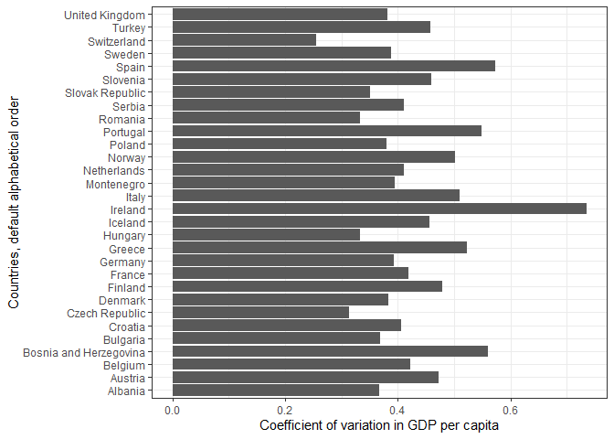

```r
#this graph is hard to interpret:
gm_reord_drop %>%
  ggplot() +
    geom_col(aes(x = country_asGiven, #x axis is the non-reordered country levels, which are still alphabetical
                 y = GDP_cv)) + #bar size is based on max GDP for each country
    coord_flip() + #flip the graph to be displayed horizontally
    theme_bw() + #nicer black and white theme
    labs(x = "Countries, default alphabetical order", #explain why country axis seems out of order
         y = "Coefficient of variation in GDP per capita") #make better data label
```

This next graph is based on the same data, but uses the column of reordered countries, and is therefore more easily interpreted. Ireland has the highest variation in its GDP data, while Switzerland had the most stable data according to the coefficent of variation metric.

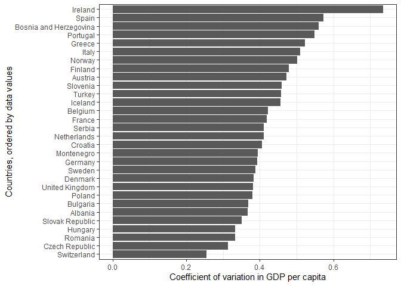

```r
#this graph is easy to intepret:
gm_reord_drop %>%
  ggplot() +
    geom_col(aes(x = country, #x axis is the reordered country levels based on max(GDP)
                 y = GDP_cv)) + #bar size is based on max GDP for each country
    coord_flip() + #flip the graph to be displayed horizontally
    theme_bw() + #nicer black and white theme
    labs(x = "Countries, ordered by data values", #explain what country axis is showing
         y = "Coefficient of variation in GDP per capita") #make better data axis label
```